# LightLogR newsletter

July 2025, Edition #01

Author

LightLogR Team

Doi

10.5281/zenodo.16308351

[figure not shown]

We are excited to bring you *light news* from the team behind **LightLogR**!

Last year, many of you contributed to our community survey - you have been patient with us and we promise it was not for nothing… We have been busy building something big and implementing your feedback into the newest version of [**LightLogR 0.9.2 Sunrise**](https://tscnlab.github.io/LightLogR/).

Let us first express our sincere appreciation to all who contributed either through the survey or feedback in general, your insights and perspective help shape our research and guide our community activities, thank you.

## Community survey insights

### Diverse & engaged community

Over half of you are specialists in *Chronobiology and Sleep Research*, with strong representation across *Neuroscience, Psychology, and Environmental Science*, demonstrating our interdisciplinary strength.

### Onboarding opportunities

A balanced mix of beginners, intermediates, and advanced users provides clear opportunities to support everyone, from detailed tutorials for newcomers to advanced customization for seasoned users.

### Growing interest & adoption

Over 50% of respondents are using or planning to use LightLogR, confirming the importance of our next phase of improvements.

#### Top scientific fields represented

[figure not shown]

#### Typical dataset duration

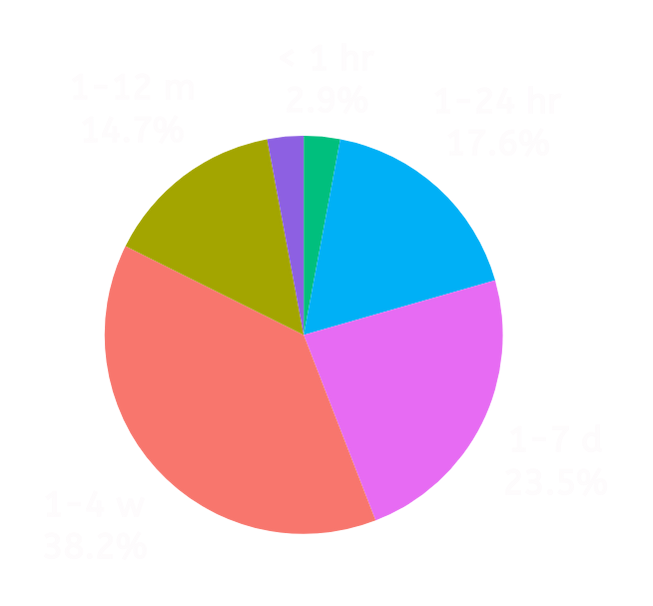

#### 10 unique scientific fields, with many researchers working across multiple domains.

## LightLogR 0.9.2 Sunrise: your priorities implemented

Here are some of the highlights in LightLogR 0.9.2 Sunrise, with even more to be found in the [changelog](https://tscnlab.github.io/LightLogR/news/index.html#lightlogr-091).

**NonePhotoperiod support**

Simply provide the coordinates of your data collection to add information on sunrise, sunset, and the duration of the photoperiod to your analysis:

- [add_photoperiod()](https://tscnlab.github.io/LightLogR/reference/photoperiod.html) adds photoperiod information to your dataset
- [extract_photoperiod()](https://tscnlab.github.io/LightLogR/reference/photoperiod.html) provides a succinct summary for photoperiod on all relevant days contained in a dataset
- [gg_photoperiod()](https://tscnlab.github.io/LightLogR/reference/gg_photoperiod.html) adds shaded areas for nighttimes in plots

**NoneMind the gaps**

- [gap_table()](https://tscnlab.github.io/LightLogR/reference/gap_table.html) for a clean summary of available and missing data
- [has_gaps()](https://tscnlab.github.io/LightLogR/reference/has_gaps.html), [has_irregulars()](https://tscnlab.github.io/LightLogR/reference/has_irregulars.html), and [extract_gaps()](https://tscnlab.github.io/LightLogR/reference/extract_gaps.html) for quick assessments
- [remove_partial_data()](https://tscnlab.github.io/LightLogR/reference/remove_partial_data.html) to remove groups with insufficient data
- [gg_gaps()](https://tscnlab.github.io/LightLogR/reference/gg_gaps.html) to visualize where gaps and irregular data occur

**NoneSpectral analysis**

Three new functions to reconstruct and integrate across light spectra for multi-spectral devices.

- [spectral_reconstruction()](https://tscnlab.github.io/LightLogR/reference/spectral_reconstruction.html) returns spectral irradiances with the help of a calibration matrix
- [spectral_integration()](https://tscnlab.github.io/LightLogR/reference/spectral_integration.html) integrates over the spectrum, either fully or in parts, optionally with action spectra and weighing factors
- [normalize_counts()](https://tscnlab.github.io/LightLogR/reference/normalize_counts.html) normalize raw counts based on sensor outputs and a gain value.

**NoneRock-solid & reproducible**

How many stars can you count in this newsletter? Well, ten times as many unit tests, **888** to be specific, ensure that the functions in LightLogR have consistent output, and remain so even with future changes.

Continuous integration, and three [new tutorials](https://tscnlab.github.io/LightLogR/articles/) ensure analysis with transparent, accessible, and standardized pipelines.

**NoneInsightful visuals, instantly**

Publication-ready plots that spotlight gaps, states, and 24-h patterns (click to enlarge).

**Heatmap**

```r
data |> gg_heatmap()
```

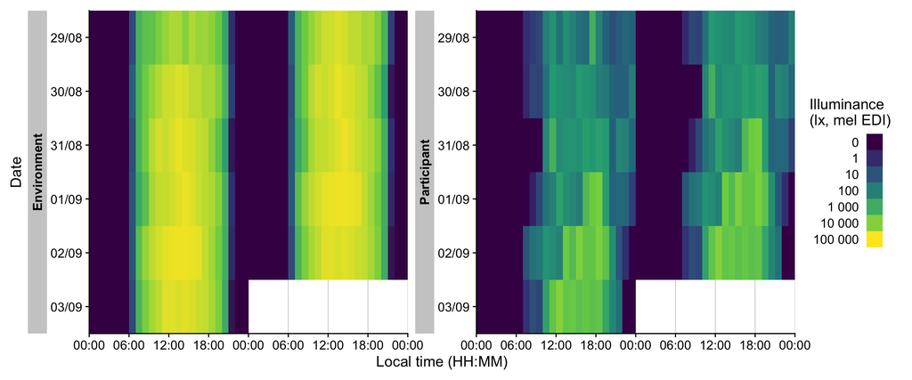

**Day/Night**

```r
data |>
  gg_days() |>
  gg_photoperiod(coordinates)
```

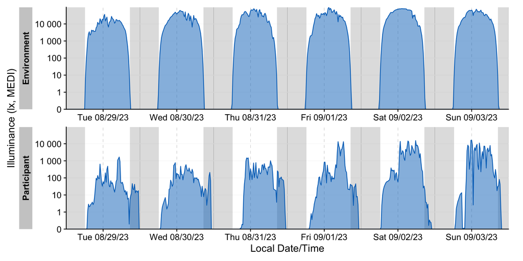

**States**

```r
data |>
  gg_days() |> gg_state(sleep)
```

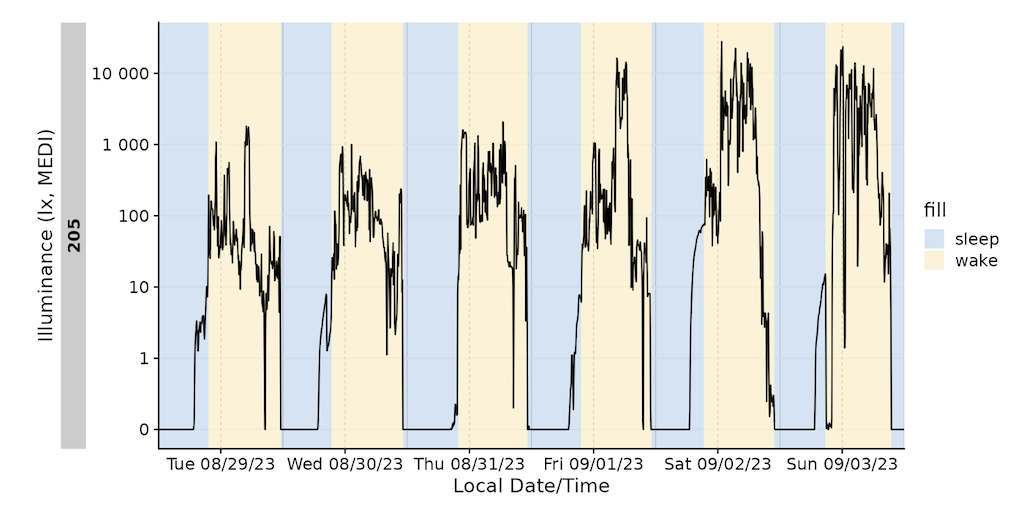

**…**

There are many more ways to visualize your data with LightLogR. Visit the [tutorial](https://tscnlab.github.io/LightLogR/articles/Visualizations.html) on visualization to learn more.

**NoneBroader device support**

We’ve added more import wrappers and are now supporting 18 different devices and counting. See the list of supported devices [here](https://tscnlab.github.io/LightLogR/reference/import_Dataset.html#devices). Let us know of any other device that should join the list.

**NoneMore metrics**

We are continuously expanding on the [number of metrics](https://tscnlab.github.io/LightLogR/index.html#metrics-1) we support with a consistent interface and have rewritten the tutorial on [metrics](https://tscnlab.github.io/LightLogR/articles/Metrics.html) because the new functionality of LightLogR makes metric summaries even easier and more flexible.

Notable additions are functions to mark up or extract special conditions from your dataset:

- [add_clusters()](https://tscnlab.github.io/LightLogR/reference/extract_clusters.html) and [extract_clusters()](https://tscnlab.github.io/LightLogR/reference/extract_clusters.html) find clusters of data, where conditions hold for a specified duration.
- [extract_states()](https://tscnlab.github.io/LightLogR/reference/extract_states.html) summarises states in your data
- [summarize_numeric()](https://tscnlab.github.io/LightLogR/reference/summarize_numeric.html)/[summarise_numeric()](https://tscnlab.github.io/LightLogR/reference/summarize_numeric.html) is a quick way to calculate averages across many groups
- [mean_daily()](https://tscnlab.github.io/LightLogR/reference/mean_daily.html) calculates average values for weekdays, weekends, and a weekday/weeken-weighted average

Dealing with many zero values in measurements of light exposure data can also be a challenge for logarithmis transformation. The pair of zero-inflation functions [log_zero_inflated()](https://tscnlab.github.io/LightLogR/reference/log_zero_inflated.html) and [exp_zero_inflated()](https://tscnlab.github.io/LightLogR/reference/exp_zero_inflated.html) help to deal with this issue in a principled way.

##### We are very happy to see so many researchers from so many disciplines utilising LightLogR in their work and we are eager to support you along this journey to further empower your data and build meaningful insights.

## LightLogR training webinars

Whether you’re starting out or optimizing your workflow, we aim to support you at every step.

- **Live walkthroughs:** Demonstrations of core features and new functions.
- **Tips & tricks:** Processing time series, reconstructing spectra, generating publication-ready visuals.
- **Dedicated Q&A:** Troubleshoot your specific use cases with our experts.
- **Tailored sessions:** Content for all levels, from onboarding to advanced custom analysis.

**First sessions launch in Q3 2025** across multiple time zones to support our global community.

[Subscribe on our website](https://www.visualdiet.org/register) to receive updates and registration links.

## Community updates

[figure not shown]

There are many places for a LightLogR sticker around the office

### Survey prize winner

Congratulations to the winner of our survey draw for a free copy of *Circadian and Visual Neuroscience*! Check your inbox.

### LightLogR stickers

For those who missed out, we have mailed LightLogR stickers - place them somewhere fun and share a photo with us!

## GLEE: a new chapter

The *Translational Sensory & Circadian Neuroscience Unit (MPS/TUM/TUMCREATE)* is launching **GLEE**, an open-source reimagining how light exposure data is collected, stored, processed, and analyzed.

[figure not shown]

### The vision

GLEE will foster knowledge exchange and drive advancements beyond the capabilities of any single research group.

### Community impact

With a focus on collaboration and engagement, GLEE aims to build a legacy of innovation and progress in understanding and managing the health impacts of global light exposure.

### Join the GLEE journey

Be part of this groundbreaking initiative that will transform light exposure research. GLEE represents our commitment to open science and collaborative research methodologies that benefit the entire scientific community.

**NoneGlobal collaboration**

Connect with researchers worldwide working on light exposure studies.

**NoneOpen-source database**

Access standardized light exposure data from diverse populations and environments.

**NoneShared resources**

Benefit from community-developed analysis tools and methodologies.

[Join us on our journey](https://www.visualdiet.org/register) and subscribe to stay up to date with GLEE.

## Subscribe & unsubscribe

You can subscribe to this newsletter (and unsubscribe) by visiting the [LightLogR mailing list](https://lists.lrz.de/mailman/listinfo/lightlogr-users).

## Cite

If you want to cite this newsletter, please do so as:

APA:

> Zauner, J., Tsukimori, E., & Spitschan, M. (2025, July). LightLogR newsletter (No. 01). https://doi.org/10.5281/zenodo.16308351

Harvard:

> Zauner, J., Tsukimori, E. & Spitschan, M. 2025. LightLogR Newsletter, no. 1, July. Available at: https://doi.org/10.5281/zenodo.16308351 (Published 22 July 2025).